# get_git_stats

If you came here from the blog part of my website, you can go back to it by clicking [here](http://rahulporuri.github.io/blog.html) or if you came here from my blogpost, you can go back to it by clicking [here](http://rahulporuri.blogspot.in/).

I wanted to look at my commit stats on Github. While Github itself displays the number of commits I've done, I wanted to try it myself. In the process, learn something maybe.

In order to look at the stats, we first need to put them all in the same file. We can run the following command to create a file with the relevant information, which we can parse using Python later in the code. If you are not working on IPython, you can run the same command without the exclamation point on the terminal. Also, I store all of my Github repositories in the home directory, ~, under a directory 'Github'. The * will look through all sub- directories for the file we want.

```python
!more ~/Github/*/.git/logs/HEAD > commit_data.dat
```

we need the time Python module because we get timestamps in the form of a 10-digit number, which we then need to convert into a date-time format we can understand.

```python
import numpy
import matplotlib.pyplot as plt
%matplotlib inline
import time
```

We cant run these commands because if you look at the file we just created, you will notice lines containing information on the directory from which the messages were added, which we ofcourse don't need. ''' dateList = [line.split()[4] for line in open('commit_data.dat')] dateList = numpy.asarray(dateList, dtype=int) print len(dateList) '''

```python
dateList = []
for line in open('commit_data.dat'):
    try:
        dateList.append(line.split()[4])
    except IndexError:
        print line

dateList = numpy.asarray(dateList, dtype=int)
print len(dateList)
```

[output not shown]

[output cut: 36 more lines]

```
::::::::::::::

::::::::::::::

/home/rahulporuri/Github/setup_files/.git/logs/HEAD

::::::::::::::

::::::::::::::

/home/rahulporuri/Github/tex/.git/logs/HEAD

::::::::::::::

380
```

time.gmtime(foo) will convert the 10-digit timestamp into a format that we can understand, as I had mentioned earlier. You can look at the following example to understand it better.

```python
time.gmtime(1452664187)
```

```
time.struct_time(tm_year=2016, tm_mon=1, tm_mday=13, tm_hour=5, tm_min=49, tm_sec=47, tm_wday=2, tm_yday=13, tm_isdst=0)
```

```python
yearList = []
monthList = []
dayList = []
hourList = []

for date in dateList:
        temp = time.gmtime(date)
        yearList.append(temp.tm_year)
        monthList.append(temp.tm_mon)
        dayList.append(temp.tm_mday)
        hourList.append(temp.tm_hour)

yearList = numpy.asarray(yearList)
monthrList = numpy.asarray(monthList)
dayList = numpy.asarray(dayList)
hourList = numpy.asarray(hourList)
```

I do list(set(fooList)) because I want to confirm that we have meaningful dates. It has happened that a few months of the year or days of the week were missing in a different dataset.

```python
print min(yearList), max(yearList)
print list(set(yearList))
print list(set(monthList))
print list(set(dayList))
print list(set(hourList))
```

```
2014 2016
[2016, 2014, 2015]
[1, 2, 3, 4, 5, 6, 7, 8, 9, 10, 11, 12]
[1, 2, 3, 4, 5, 6, 7, 8, 9, 10, 11, 12, 13, 14, 15, 16, 17, 18, 19, 20, 21, 22, 23, 24, 25, 26, 27, 28, 29, 30, 31]
[0, 1, 2, 3, 4, 5, 6, 7, 8, 9, 10, 11, 12, 13, 14, 15, 16, 17, 18, 19, 20, 21, 23]
```

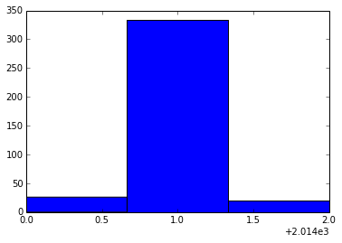

```python
plt.hist(yearList, bins=3)
```

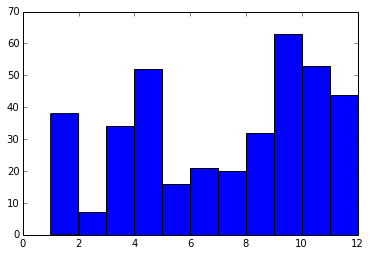

```python
plt.hist(monthList,bins= 11)
```

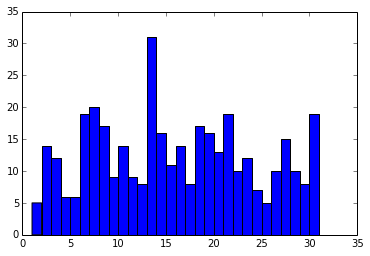

```python
plt.hist(dayList, bins=30)
```

note that the following plot needs to be shifted right by +0530 because I didn't bother doing so myself. The time stamps were with respect to UTC and not local time.

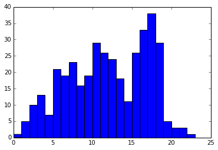

```python
plt.hist(hourList, bins=23)
```

If you came here from the blog part of my website, you can go back to it by clicking [here](http://rahulporuri.github.io/blog.html) or if you came here from my blogpost, you can go back to it by clicking [here](http://rahulporuri.blogspot.in/).